# Codebook

**Authors:** Lauren Baker  
Documenting existing data files of DaanMatch with information about location, owner, "version", source etc.

```python
import boto3
import numpy as np
import pandas as pd
pd.plotting.register_matplotlib_converters()
import matplotlib.pyplot as plt
%matplotlib inline
from collections import Counter
import statistics
```

```python
client = boto3.client('s3')
resource = boto3.resource('s3')
my_bucket = resource.Bucket('daanmatchdatafiles')
```

# CSR Spent 17-18.xlsx

## TOC:

- About this dataset
- What's in this dataset
- Codebook
  - Missing values
  - Summary statistics
- Columns
  - Url
  - Company Name
  - CSR Spent 17-18
  - Date of Incorporation
  - Class
  - RoC
  - Category
  - Sub Category
  - Listing Status
  - Registered Address
  - Zipcode
  - State
  - Email ID
  - Paid-up Capital (in INR Cr.)
  - Authorized Capital (in INR Cr.)

**About this dataset**  
Data provided by: Unknown.  
Source: https://daanmatchdatafiles.s3.us-west-1.amazonaws.com/DaanMatch_DataFiles/CSR+Spent+17-18.xlsx  
Type: xlsx  
Last Modified: May 29, 2021, 19:54:24 (UTC-07:00)  
Size: 3.4 MB

```python
path = "s3://daanmatchdatafiles/CSR Spent 17-18.xlsx"
csr_spent_17_18 = pd.ExcelFile(path)
print(csr_spent_17_18.sheet_names)
```

```
['CSR Spent 17-18']
```

```python
csr_spent_17_18 = csr_spent_17_18.parse('CSR Spent 17-18')
csr_spent_17_18.head()
```

|  | Url | Company Name | CSR Spent 17-18 | Date of Incorporation | Class | RoC | Category | Sub Category | Listing Status | Registered Address | Zipcode | State | Email ID | Paid-up Capital (in INR Cr.) | Authorized Capital (in INR Cr.) |
| --- | --- | --- | --- | --- | --- | --- | --- | --- | --- | --- | --- | --- | --- | --- | --- |
| 0 | https://csr.gov.in/companyprofile/dashboard.ph... | Reliance Industries Limited | 7450400000 | 1973-05-08 | Public | RoC-Mumbai | Company limited by Shares | Non-govt company | Listed | 3 RD FLOORMAKER CHAMBER IV222 NARIMAN POINT 4... | 400021.0 | Maharashtra | sandeep.deshmukh@ril.com | ₹ 6,333.50 | ₹ 15,000.00 |
| 1 | https://csr.gov.in/companyprofile/dashboard.ph... | Oil And Natural Gas Corporation Limited | 4820700000 | 1993-06-23 | Public | RoC-Delhi | Company limited by Shares | Union Govt company | Listed | Plot No. 5A- 5BNelson Mandela Road,Vasant Kunj... | 110070.0 | Delhi | secretariat@ongc.co.in | ₹ 6,416.62 | ₹ 15,000.00 |
| 2 | https://csr.gov.in/companyprofile/dashboard.ph... | Tata Consultancy Services Limited | 4000000000 | 1995-01-19 | Public | RoC-Mumbai | Company limited by Shares | Non-govt company | Listed | 9TH FLOOR, NIRMAL BUILDINGNARIMAN POINT 400021 | 400021.0 | Maharashtra | rajendra.moholkar@tcs.com | ₹ 197.04 | ₹ 565.08 |
| 3 | https://csr.gov.in/companyprofile/dashboard.ph... | Hdfc Bank Limited | 3745500000 | 1994-08-30 | Public | RoC-Mumbai | Company limited by Shares | Non-govt company | Listed | HDFC BANK HOUSESENAPATI BAPAT MARGLOWER PAREL ... | 400013.0 | Maharashtra | sanjay.dongre@hdfcbank.com | ₹ 517.61 | ₹ 650.00 |
| 4 | https://csr.gov.in/companyprofile/dashboard.ph... | Indian Oil Corpn. Limited | 3310100000 | 1959-06-30 | Public | RoC-Mumbai | Company limited by Shares | Union Govt company | Listed | Indian Oil Bhavan, G-9 All Yavar Jung Marg,BAN... | 400051.0 | Maharashtra | kgwalani@indianoil.in | ₹ 4,855.90 | ₹ 6,000.00 |

**What's in this dataset?**

```python
print("Shape:", csr_spent_17_18.shape)
print("Rows:", csr_spent_17_18.shape[0])
print("Columns:", csr_spent_17_18.shape[1])
print("Each row is a company.")
```

```
Shape: (20975, 15)
Rows: 20975
Columns: 15
Each row is a company.
```

```python
csr_spent_17_18_columns = [column for column in csr_spent_17_18.columns]
csr_spent_17_18_description = ["Link to the company's website.",
                               "Name of Company.",
                               "Amount of money spent on CSR in the fiscal year 2017-18.",
                               "Timestamp of date of incorporation: YYYY-MM-DD.",
                               "Class of Company: Private or Public.",
                               "Registrar of Companies, an office under the MCA.",
                               "Category of Company: Limited by Shares, Limited by Guarantee, Unlimited Company.",
                               "Subcategory of Company: Non-govt, Union Gtvt, State Govt, Subsidiary of Foreign Company, Guarantee and Association Company.",
                               "Lisitng status: Listed or Unlisited.",
                               "Address of the registered office.",
                               "Zipcode of the registered office.",
                               "State the company is located in.",
                               "Email address.",
                               "Actual amount that is paid by shareholders to the company.",
                               "Maximum value of shares that the company is legally authorized to issue to the shareholders."]
csr_spent_17_18_dtypes = [dtype for dtype in csr_spent_17_18.dtypes]

data = {"Column Name": csr_spent_17_18_columns, "Description": csr_spent_17_18_description, "Type": csr_spent_17_18_dtypes}
csr_spent_17_18_codebook = pd.DataFrame(data)
csr_spent_17_18_codebook.style.set_properties(subset=['Description'], **{'width': '600px'})
```

|  | Column Name | Description | Type |
| --- | --- | --- | --- |
| 0 | Url | Link to the company's website. | object |
| 1 | Company Name | Name of Company. | object |
| 2 | CSR Spent 17-18 | Amount of money spent on CSR in the fiscal year 2017-18. | int64 |
| 3 | Date of Incorporation | Timestamp of date of incorporation: YYYY-MM-DD. | object |
| 4 | Class | Class of Company: Private or Public. | object |
| 5 | RoC | Registrar of Companies, an office under the MCA. | object |
| 6 | Category | Category of Company: Limited by Shares, Limited by Guarantee, Unlimited Company. | object |
| 7 | Sub Category | Subcategory of Company: Non-govt, Union Gtvt, State Govt, Subsidiary of Foreign Company, Guarantee and Association Company. | object |
| 8 | Listing Status | Lisitng status: Listed or Unlisited. | object |
| 9 | Registered Address | Address of the registered office. | object |
| 10 | Zipcode | Zipcode of the registered office. | float64 |
| 11 | State | State the company is located in. | object |
| 12 | Email ID | Email address. | object |
| 13 | Paid-up Capital (in INR Cr.) | Actual amount that is paid by shareholders to the company. | object |
| 14 | Authorized Capital (in INR Cr.) | Maximum value of shares that the company is legally authorized to issue to the shareholders. | object |

**Missing values**

```python
csr_spent_17_18.isnull().sum()
```

```
Url                                0
Company Name                       0
CSR Spent 17-18                    0
Date of Incorporation              0
Class                              0
RoC                                0
Category                           0
Sub Category                       0
Listing Status                     0
Registered Address                 3
Zipcode                            3
State                              0
Email ID                           0
Paid-up Capital (in INR Cr.)       0
Authorized Capital (in INR Cr.)    0
dtype: int64
```

**Summary statistics**

```python
csr_spent_17_18.describe()
```

|  | CSR Spent 17-18 | Zipcode |
| --- | --- | --- |
| count | 2.097500e+04 | 20972.000000 |
| mean | 6.410293e+06 | 391159.803071 |
| std | 9.126581e+07 | 200085.889143 |
| min | 0.000000e+00 | 0.000000 |
| 25% | 0.000000e+00 | 201306.000000 |
| 50% | 0.000000e+00 | 400063.000000 |
| 75% | 1.500000e+06 | 560025.000000 |
| max | 7.450400e+09 | 851134.000000 |

## Columns

### Url

```python
column = csr_spent_17_18["Url"]
column
```

```
0        https://csr.gov.in/companyprofile/dashboard.ph...
1        https://csr.gov.in/companyprofile/dashboard.ph...
2        https://csr.gov.in/companyprofile/dashboard.ph...
3        https://csr.gov.in/companyprofile/dashboard.ph...
4        https://csr.gov.in/companyprofile/dashboard.ph...
                               ...
20970    https://csr.gov.in/companyprofile/dashboard.ph...
20971    https://csr.gov.in/companyprofile/dashboard.ph...
20972    https://csr.gov.in/companyprofile/dashboard.ph...
20973    https://csr.gov.in/companyprofile/dashboard.ph...
20974    https://csr.gov.in/companyprofile/dashboard.ph...
Name: Url, Length: 20975, dtype: object
```

```python
print("No. of unique values:", len(column.unique()))

# Check for duplicates
counter = dict(Counter(column))
duplicates = { key:value for key, value in counter.items() if value > 1}
print("Duplicates:", duplicates)
```

```
No. of unique values: 20975
Duplicates: {}
```

### Company Name

Name of Company.

```python
column = csr_spent_17_18["Company Name"]
column
```

```
0                              Reliance Industries Limited
1                  Oil And Natural Gas Corporation Limited
2                        Tata Consultancy Services Limited
3                                        Hdfc Bank Limited
4                                Indian Oil Corpn. Limited
                               ...
20970              Designers Point (india) Private Limited
20971                                    V2 Retail Limited
20972    Tt Electronics Sensing And Control India Priva...
20973                             Time Cap Pharma Labs Ltd
20974           Delhi International Airport Privatelimited
Name: Company Name, Length: 20975, dtype: object
```

```python
print("No. of unique values:", len(column.unique()))

# Check for duplicates
counter = dict(Counter(column))
duplicates = { key:value for key, value in counter.items() if value > 1}
#print("Duplicates:", duplicates)
if len(duplicates) > 0:
    print("No. of duplicates:", len(duplicates))
```

```
No. of unique values: 20667
No. of duplicates: 307
```

```python
csr_spent_17_18[csr_spent_17_18['Company Name'].isin(duplicates)].sort_values('Company Name')
```

|  | Url | Company Name | CSR Spent 17-18 | Date of Incorporation | Class | RoC | Category | Sub Category | Listing Status | Registered Address | Zipcode | State | Email ID | Paid-up Capital (in INR Cr.) | Authorized Capital (in INR Cr.) |
| --- | --- | --- | --- | --- | --- | --- | --- | --- | --- | --- | --- | --- | --- | --- | --- |
| 1020 | https://csr.gov.in/companyprofile/dashboard.ph... | 3d Plm Software Solutions Limited | 15300000 | 2001-12-14 | Public | RoC-Mumbai | Company limited by Shares | Non-govt company | Listed | PLANT 11, 3RD FLOORPIROJSHANAGAR, VIKHROLI (WE... | 400079.0 | Maharashtra | Sunipa_GHOSH@3dplmsoftware.com | ₹ 344.81 | ₹ 757.60 |
| 15005 | https://csr.gov.in/companyprofile/dashboard.ph... | 3d Plm Software Solutions Limited | 0 | 2001-12-14 | Public | RoC-Mumbai | Company limited by Shares | Non-govt company | Unlisted | PLANT 11, 3RD FLOORPIROJSHANAGAR, VIKHROLI (WE... | 400079.0 | Maharashtra | Sunipa_GHOSH@3dplmsoftware.com | ₹ 513.38 | ₹ 757.60 |
| 3963 | https://csr.gov.in/companyprofile/dashboard.ph... | A P I Ispat And Powertech Privatelimited | 2500000 | 2004-10-08 | Private | RoC-Chhattisgarh | Company limited by Shares | Non-govt company | Unlisted | Near Industrial Growth Center, Phase II,Siltar... | 493111.0 | Chhattisgarh | ravi@realispat.com | ₹ 44.04 | ₹ 45.00 |
| 17770 | https://csr.gov.in/companyprofile/dashboard.ph... | A P I Ispat And Powertech Privatelimited | 0 | 2004-10-08 | Private | RoC-Delhi | Company limited by Shares | Non-govt company | Unlisted | D-14 UDYOG NAGAR, MAIN ROHTAK ROAD 110041 | 110041.0 | Delhi | ravi@realispat.com | ₹ 44.04 | ₹ 45.00 |
| 4170 | https://csr.gov.in/companyprofile/dashboard.ph... | Aadhar Housing Finance Limited | 2300000 | 1990-11-26 | Public | RoC-Bangalore | Company limited by Shares | Non-govt company | Unlisted | No.3, 'JVT Towers', 8th A Main Road,Sampangi R... | 560027.0 | Karnataka | lourdunathan.MS@dvhousing.com | ₹ 21.21 | ₹ 220.00 |
| ... | ... | ... | ... | ... | ... | ... | ... | ... | ... | ... | ... | ... | ... | ... | ... |
| 5986 | https://csr.gov.in/companyprofile/dashboard.ph... | Zen Securities Ltd | 1100000 | 1994-05-11 | Public | RoC-Hyderabad | Company limited by Shares | Non-govt company | Unlisted | 3rd floor,Vamsee Estates, 6-3-788/32Ameerpet ... | 500016.0 | Telangana | md@zenmoney.com | ₹ 2.43 | ₹ 4.00 |
| 3326 | https://csr.gov.in/companyprofile/dashboard.ph... | Zota Health Care Limited | 3200000 | 2000-07-12 | Public | RoC-Ahmedabad | Company limited by Shares | Non-govt company | Listed | ZOTA HOUSE 2/896 HIRA MODI STREETSAGRAMPURA 3... | 395002.0 | Gujarat | zotahealth@yahoo.com | ₹ 17.54 | ₹ 20.00 |
| 12596 | https://csr.gov.in/companyprofile/dashboard.ph... | Zota Health Care Limited | 0 | 2000-07-12 | Public | RoC-Ahmedabad | Company limited by Shares | Non-govt company | Unlisted | ZOTA HOUSE 2/896 HIRA MODI STREETSAGRAMPURA 3... | 395002.0 | Gujarat | zotahealth@yahoo.com | ₹ 17.54 | ₹ 20.00 |
| 14508 | https://csr.gov.in/companyprofile/dashboard.ph... | Zylog Plastalloys Private Limited | 0 | 1984-06-05 | Private | RoC-Ahmedabad | Company limited by Shares | Non-govt company | Unlisted | 401,-OFFICE, AKSHAT COMPLEX, NR. PARSHWA COMPL... | 380015.0 | Gujarat | a.damani@zylogplastalloys.com | ₹ 0.75 | ₹ 0.75 |
| 10982 | https://csr.gov.in/companyprofile/dashboard.ph... | Zylog Plastalloys Private Limited | 0 | 1984-06-05 | Private | RoC-Mumbai | Company limited by Shares | Non-govt company | Unlisted | C/O.JITENDRA C SHAH, 14 DIVYA MAHAL GYAN MANDI... | 400028.0 | Maharashtra | a.damani@zylogplastalloys.com | ₹ 0.75 | ₹ 0.75 |

615 rows × 15 columns

Duplicates in `Companay Name` does not mean the rows are duplicates. Many of the duplicates appear to be the same company, yet they have different Class, Listing Status, or CSR Spent 17-18 values.

### CSR Spent 17-18

Amount of money spent on CSR in the fiscal year 2017-18.

```python
column = csr_spent_17_18["CSR Spent 17-18"]
column
```

```
0        7450400000
1        4820700000
2        4000000000
3        3745500000
4        3310100000
            ...
20970             0
20971             0
20972             0
20973             0
20974             0
Name: CSR Spent 17-18, Length: 20975, dtype: int64
```

```python
#Check how many unique values
print("No. of unique values:", len(column.unique()))

# Check for duplicates
counter = dict(Counter(column))
duplicates = { key:value for key, value in counter.items() if value > 1}
#print("Duplicates:", duplicates)
if len(duplicates) > 0:
    print("No. of duplicates:", len(duplicates))

#Check how many values are 0
print("No. of 0 values:", len(column[column == 0]))

print('Max:', max(column))
print("Min:", min(column))
```

```
No. of unique values: 749
No. of duplicates: 360
No. of 0 values: 12783
Max: 7450400000
Min: 0
```

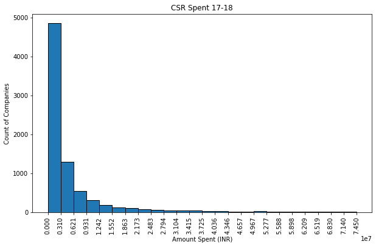

```python
bins= np.linspace(0, 74504000, 25)
plt.figure(figsize = (10, 6))
plt.hist(column[column != 0], bins=bins, edgecolor="k")
plt.title('CSR Spent 17-18')
plt.xlabel('Amount Spent (INR)')
plt.ylabel('Count of Companies')
plt.xticks(bins, rotation = 90);
```

```python
#Statistics
column.describe()
```

```
count    2.097500e+04
mean     6.410293e+06
std      9.126581e+07
min      0.000000e+00
25%      0.000000e+00
50%      0.000000e+00
75%      1.500000e+06
max      7.450400e+09
Name: CSR Spent 17-18, dtype: float64
```

### Date of Incorporation

Timestamp of date of incorporation: YYYY-MM-DD.

```python
column = csr_spent_17_18["Date of Incorporation"]
column
```

```
0        1973-05-08
1        1993-06-23
2        1995-01-19
3        1994-08-30
4        1959-06-30
            ...
20970    1992-09-02
20971    2001-07-23
20972    2006-02-14
20973    1988-02-19
20974    2006-03-01
Name: Date of Incorporation, Length: 20975, dtype: object
```

```python
#Check how many unique values
print("No. of unique values:", len(column.unique()))

# Check for duplicates
counter = dict(Counter(column))
duplicates = { key:value for key, value in counter.items() if value > 1}
#print("Duplicates:", duplicates)
if len(duplicates) > 0:
    print("No. of duplicates:", len(duplicates))

#Check how many values are 0
print("No. of 0 values:", len(column[column == 0]))

print('Max:', max(column))
print("Min:", min(column))
```

```
No. of unique values: 9202
No. of duplicates: 5119
No. of 0 values: 0
Max: 2017-06-02
Min: 1863-07-15
```

```python
years = column.apply(lambda x: int(x[:4]))
counter = dict(Counter(years))
count = { key:[value] for key, value in counter.items()}
table = pd.DataFrame.from_dict(count)
table = table.melt(var_name="Date", value_name="Count")
print("No. of unique values:", table.shape[0])
table
```

```
No. of unique values: 124
```

|  | Date | Count |
| --- | --- | --- |
| 0 | 1973 | 113 |
| 1 | 1993 | 481 |
| 2 | 1995 | 884 |
| 3 | 1994 | 639 |
| 4 | 1959 | 29 |
| ... | ... | ... |
| 119 | 1903 | 1 |
| 120 | 1873 | 1 |
| 121 | 1871 | 2 |
| 122 | 1917 | 2 |
| 123 | 1877 | 1 |

124 rows × 2 columns

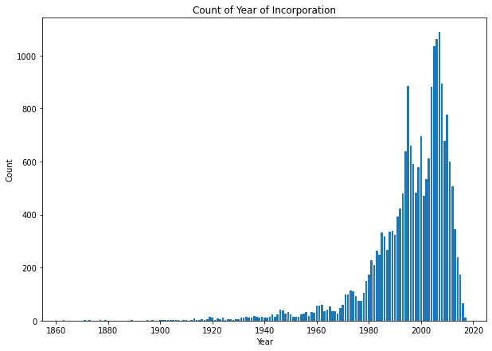

```python
# Plot of number of each year
plt.figure(figsize = (10, 7))
plt.bar(table["Date"], table["Count"])
plt.title("Count of Year of Incorporation")
plt.ylabel("Count")
plt.xlabel("Year");
```

### Class

Class of Company: Private or Public.

```python
column = csr_spent_17_18["Class"]
column
```

```
0         Public
1         Public
2         Public
3         Public
4         Public
          ...
20970    Private
20971     Public
20972    Private
20973     Public
20974    Private
Name: Class, Length: 20975, dtype: object
```

```python
print("Unique values:", column.unique())
print("No. of unique values:", len(column.unique()))

# Number of empty strings
print("Empty strings:", sum(column == " "))

# Table of number of each class
table = column.value_counts().rename_axis('Class').reset_index(name='Count')
table
```

```
Unique values: ['Public' 'Private' 'Private(One Person Company)']
No. of unique values: 3
Empty strings: 0
```

|  | Class | Count |
| --- | --- | --- |
| 0 | Private | 14411 |
| 1 | Public | 6563 |
| 2 | Private(One Person Company) | 1 |

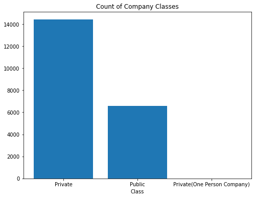

```python
# Plot number of each class
plt.figure(figsize = (8, 6))
plt.bar(table["Class"], table["Count"])
plt.title("Count of Company Classes")
plt.xlabel("Class")
plt.show()
```

### RoC

Registrar of Companies, an office under the MCA.

```python
column = csr_spent_17_18["RoC"]
column
```

```
0           RoC-Mumbai
1            RoC-Delhi
2           RoC-Mumbai
3           RoC-Mumbai
4           RoC-Mumbai
             ...
20970        RoC-Delhi
20971        RoC-Delhi
20972        RoC-Delhi
20973    RoC-Hyderabad
20974        RoC-Delhi
Name: RoC, Length: 20975, dtype: object
```

```python
print("Unique values:", column.unique())
print("No. of unique values:", len(column.unique()))

# Table of number of each class
table = column.value_counts().rename_axis('RoC').reset_index(name='Count')
table
```

```
Unique values: ['RoC-Mumbai' 'RoC-Delhi' 'RoC-Bangalore' 'RoC-Cuttack' 'RoC-Ahmedabad'
 'RoC-Hyderabad' 'RoC-Pune' 'RoC-Kolkata' 'RoC-Chennai'
 'RoC-Himachal Pradesh' 'RoC-Gwalior' 'RoC-Jaipur' 'RoC-Chandigarh'
 'ROC-Ernakulam' 'RoC-Coimbatore' 'RoC-Uttarakhand' 'RoC-Goa' 'RoC-Kanpur'
 'RoC-Chhattisgarh' 'RoC-Patna' 'RoC-Shillong' 'RoC-Jharkhand'
 'RoC-Pondicherry' 'RoC-Jammu' 'Unclassified']
No. of unique values: 25
```

|  | RoC | Count |
| --- | --- | --- |
| 0 | RoC-Mumbai | 5395 |
| 1 | RoC-Delhi | 4141 |
| 2 | RoC-Bangalore | 1752 |
| 3 | RoC-Chennai | 1575 |
| 4 | RoC-Hyderabad | 1473 |
| 5 | RoC-Kolkata | 1444 |
| 6 | RoC-Ahmedabad | 1355 |
| 7 | RoC-Pune | 1001 |
| 8 | RoC-Kanpur | 471 |
| 9 | RoC-Coimbatore | 364 |
| 10 | RoC-Chandigarh | 334 |
| 11 | RoC-Jaipur | 330 |
| 12 | ROC-Ernakulam | 311 |
| 13 | RoC-Gwalior | 253 |
| 14 | RoC-Cuttack | 141 |
| 15 | RoC-Goa | 135 |
| 16 | RoC-Chhattisgarh | 112 |
| 17 | RoC-Shillong | 104 |
| 18 | RoC-Himachal Pradesh | 75 |
| 19 | RoC-Patna | 59 |
| 20 | RoC-Uttarakhand | 50 |
| 21 | RoC-Jharkhand | 37 |
| 22 | Unclassified | 25 |
| 23 | RoC-Jammu | 22 |
| 24 | RoC-Pondicherry | 16 |

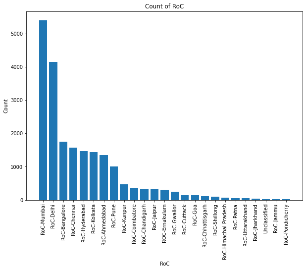

```python
# Plot number of each class
plt.figure(figsize = (10, 7))
plt.bar(table["RoC"], table["Count"])
plt.title("Count of RoC")
plt.xlabel("RoC")
plt.ylabel('Count')
plt.xticks(rotation = 90)
plt.show()
```

### Category

Category of Company: Limited by Shares, Limited by Guarantee, Unlimited Company.

```python
column = csr_spent_17_18["Category"]
column
```

```
0        Company limited by Shares
1        Company limited by Shares
2        Company limited by Shares
3        Company limited by Shares
4        Company limited by Shares
                   ...
20970    Company limited by Shares
20971    Company limited by Shares
20972    Company limited by Shares
20973    Company limited by Shares
20974    Company limited by Shares
Name: Category, Length: 20975, dtype: object
```

```python
print("Unique values:", column.unique())
print("No. of unique values:", len(column.unique()))

# Table of number of each category
table = column.value_counts().rename_axis('Category').reset_index(name='Count')
table
```

```
Unique values: ['Company limited by Shares' 'Company Limited by Guarantee'
 'Unlimited Company']
No. of unique values: 3
```

|  | Category | Count |
| --- | --- | --- |
| 0 | Company limited by Shares | 20862 |
| 1 | Company Limited by Guarantee | 87 |
| 2 | Unlimited Company | 26 |

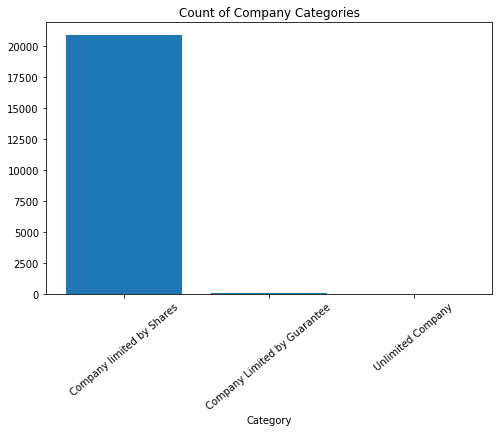

```python
# Plot number of each Category
plt.figure(figsize = (8, 5))
plt.bar(table["Category"], table["Count"])
plt.title("Count of Company Categories")
plt.xlabel("Category")
plt.xticks(rotation = 40)
plt.show()
```

### Sub Category

Subcategory of Company: Non-govt, Union Gtvt, State Govt, Subsidiary of Foreign Company, Guarantee and Association Company.

```python
column = csr_spent_17_18["Sub Category"]
column
```

```
0          Non-govt company
1        Union Govt company
2          Non-govt company
3          Non-govt company
4        Union Govt company
                ...
20970      Non-govt company
20971      Non-govt company
20972      Non-govt company
20973      Non-govt company
20974      Non-govt company
Name: Sub Category, Length: 20975, dtype: object
```

```python
print("Unique values:", column.unique())
print("No. of unique values:", len(column.unique()))

# Table of number of each sub-category
table = column.value_counts().rename_axis('Sub-category').reset_index(name='Count')
table
```

```
Unique values: ['Non-govt company' 'Union Govt company' 'State Govt company'
 'Subsidiary of Foreign Company' 'Guarantee and Association comp']
No. of unique values: 5
```

|  | Sub-category | Count |
| --- | --- | --- |
| 0 | Non-govt company | 19767 |
| 1 | Subsidiary of Foreign Company | 653 |
| 2 | State Govt company | 317 |
| 3 | Union Govt company | 215 |
| 4 | Guarantee and Association comp | 23 |

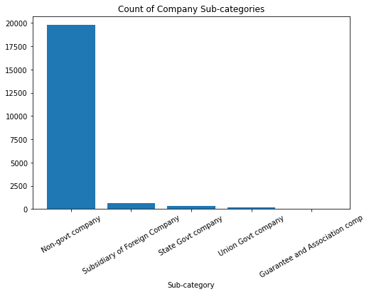

```python
# Plot number of each sub-category
plt.figure(figsize = (8, 5))
plt.bar(table["Sub-category"], table["Count"])
plt.title("Count of Company Sub-categories")
plt.xlabel("Sub-category")
plt.xticks(rotation = 30)
plt.show()
```

### Listing Status

Lisitng status: Listed or Unlisited.

```python
column = csr_spent_17_18["Listing Status"]
column
```

```
0          Listed
1          Listed
2          Listed
3          Listed
4          Listed
           ...
20970    Unlisted
20971      Listed
20972    Unlisted
20973    Unlisted
20974    Unlisted
Name: Listing Status, Length: 20975, dtype: object
```

```python
print("Unique values:", column.unique())
print("No. of unique values:", len(column.unique()))

# Table of number of each category
table = column.value_counts().rename_axis('Listing Status').reset_index(name='Count')
table
```

```
Unique values: ['Listed' 'Unlisted']
No. of unique values: 2
```

|  | Listing Status | Count |
| --- | --- | --- |
| 0 | Unlisted | 18943 |
| 1 | Listed | 2032 |

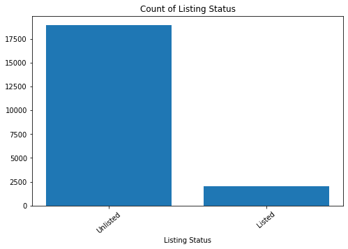

```python
# Plot number of lisiting status'
plt.figure(figsize = (8, 5))
plt.bar(table["Listing Status"], table["Count"])
plt.title("Count of Listing Status")
plt.xlabel("Listing Status")
plt.xticks(rotation = 40)
plt.show()
```

### Registered Address

Address of the registered office.

```python
column = csr_spent_17_18["Registered Address"]
column
```

```
0        3 RD FLOORMAKER CHAMBER IV222 NARIMAN POINT  4...
1        Plot No. 5A- 5BNelson Mandela Road,Vasant Kunj...
2          9TH FLOOR, NIRMAL BUILDINGNARIMAN POINT  400021
3        HDFC BANK HOUSESENAPATI BAPAT MARGLOWER PAREL ...
4        Indian Oil Bhavan, G-9 All Yavar Jung Marg,BAN...
                               ...
20970                G-194, LANE NO.13SAINIK FARMS  110062
20971    KHASRA  NO. 928, EXTENDED LAL DORA ABADIVILLAG...
20972    H-2/207, 2nd FloorApra North EX Plaza, Netaji ...
20973         NATCO HOUSE , ROAD NO.2BANJARA HILLS  000000
20974    New Udaan Bhawan, Opp. Terminal-3,Indira Gandh...
Name: Registered Address, Length: 20975, dtype: object
```

```python
# Number of invalid addresses
print("Invalid:", sum(column == "      IN"))
# -1 from invalid value
print("No. of null values:", sum(column.isnull()))
print("No. of unique values:", len(column.unique()) - 1)
```

```
Invalid: 0
No. of null values: 3
No. of unique values: 19586
```

```python
# Check for duplicates
counter = dict(Counter(column))
duplicates = { key:[value] for key, value in counter.items() if value > 1}
print("No. of Duplicates:", len(duplicates))

table = pd.DataFrame.from_dict(duplicates)
table = table.melt(var_name="Duplicate Registered Addresses", value_name="Count").sort_values(by=["Count"], ascending=False).reset_index(drop=True)
table
```

```
No. of Duplicates: 932
```

|  | Duplicate Registered Addresses | Count |
| --- | --- | --- |
| 0 | 138, Ansal Chamber - IIBikaji Cama Place 110066 | 15 |
| 1 | 2nd Floor, F-7, Block B-1,Mohan Cooperative In... | 12 |
| 2 | C/o The Tata Power Company Limited, CorporateC... | 12 |
| 3 | Edelweiss House, Off. C.S.T Road,Kalina, 400098 | 11 |
| 4 | 301-303, Mercantile House15, Kasturba Gandhi M... | 10 |
| ... | ... | ... |
| 927 | VIRAJ IMPEX HOUSE47, P D' MELLO ROAD, 400009 | 2 |
| 928 | KCI PLAZA, 7TH FLOOR23C, ASHUTOSH CHOWDHURY AV... | 2 |
| 929 | FLAT No. 621-A, 6th FLOOR,DEVIKA TOWERS, 6, NE... | 2 |
| 930 | D-64,Defence Colony, 110024 | 2 |
| 931 | M-11, MIDDLE CIRCLECONNAUGHT CIRCUS 110001 | 2 |

932 rows × 2 columns

```python
csr_spent_17_18[csr_spent_17_18["Registered Address"].isin(duplicates)].sort_values('Registered Address')
```

|  | Url | Company Name | CSR Spent 17-18 | Date of Incorporation | Class | RoC | Category | Sub Category | Listing Status | Registered Address | Zipcode | State | Email ID | Paid-up Capital (in INR Cr.) | Authorized Capital (in INR Cr.) |
| --- | --- | --- | --- | --- | --- | --- | --- | --- | --- | --- | --- | --- | --- | --- | --- |
| 705 | https://csr.gov.in/companyprofile/dashboard.ph... | Astral Poly Technik Limited | 24200000 | 1996-03-25 | Public | RoC-Ahmedabad | Company limited by Shares | Non-govt company | Listed | "ASTRAL HOUSE", 207/1, B/H RAJPATH CLUB,OFF S.... | 380059.0 | Gujarat | co@astralpipes.com | ₹ 11.98 | ₹ 15.00 |
| 11686 | https://csr.gov.in/companyprofile/dashboard.ph... | Resinova Chemie Limited | 0 | 2009-09-16 | Public | RoC-Ahmedabad | Company limited by Shares | Non-govt company | Unlisted | "ASTRAL HOUSE", 207/1, B/H RAJPATH CLUB,OFF S.... | 380059.0 | Gujarat | co@astralpipes.com | ₹ 0.29 | ₹ 5.75 |
| 18774 | https://csr.gov.in/companyprofile/dashboard.ph... | Bhushan Aviation Limited | 0 | 2007-12-03 | Public | RoC-Delhi | Company limited by Shares | Non-govt company | Unlisted | "Bhushan Center" 11th FloorHyatt Regency Compl... | 110066.0 | Delhi | bhushanaviation@in.com | ₹ 1.01 | ₹ 1.10 |
| 17074 | https://csr.gov.in/companyprofile/dashboard.ph... | Bhushan Infrastructure Private Limited | 0 | 2006-09-16 | Private | RoC-Delhi | Company limited by Shares | Non-govt company | Unlisted | "Bhushan Center" 11th FloorHyatt Regency Compl... | 110066.0 | Delhi | onlinefiling@gmail.com | ₹ 39.58 | ₹ 40.00 |
| 348 | https://csr.gov.in/companyprofile/dashboard.ph... | The India Cements Limited | 55400000 | 1946-02-21 | Public | RoC-Chennai | Company limited by Shares | Non-govt company | Listed | "DHUN BUILDING"827, ANNA SALAI, 600002 | 600002.0 | Tamil Nadu | investor@indiacements.co.in | ₹ 308.15 | ₹ 535.00 |
| ... | ... | ... | ... | ... | ... | ... | ... | ... | ... | ... | ... | ... | ... | ... | ... |
| 12596 | https://csr.gov.in/companyprofile/dashboard.ph... | Zota Health Care Limited | 0 | 2000-07-12 | Public | RoC-Ahmedabad | Company limited by Shares | Non-govt company | Unlisted | ZOTA HOUSE 2/896 HIRA MODI STREETSAGRAMPURA 3... | 395002.0 | Gujarat | zotahealth@yahoo.com | ₹ 17.54 | ₹ 20.00 |
| 3326 | https://csr.gov.in/companyprofile/dashboard.ph... | Zota Health Care Limited | 3200000 | 2000-07-12 | Public | RoC-Ahmedabad | Company limited by Shares | Non-govt company | Listed | ZOTA HOUSE 2/896 HIRA MODI STREETSAGRAMPURA 3... | 395002.0 | Gujarat | zotahealth@yahoo.com | ₹ 17.54 | ₹ 20.00 |
| 2121 | https://csr.gov.in/companyprofile/dashboard.ph... | Desiccant Rotors International Privatelimited | 6000000 | 1984-02-06 | Private | RoC-Delhi | Company limited by Shares | Non-govt company | Unlisted | NaN | NaN | Delhi | dpahwa@pawa.com | ₹ 0.04 | ₹ 0.25 |
| 15148 | https://csr.gov.in/companyprofile/dashboard.ph... | Sarla Holdings Private Limited | 0 | 2001-07-25 | Private | RoC-Delhi | Company limited by Shares | Non-govt company | Unlisted | NaN | NaN | Delhi | rstiwari@sarlagroup.com | ₹ 18.67 | ₹ 46.00 |
| 19368 | https://csr.gov.in/companyprofile/dashboard.ph... | Central Coalfields Limited | 0 | 1956-09-05 | Private | RoC-Jharkhand | Company limited by Shares | Union Govt company | Unlisted | NaN | NaN | Jharkhand | cosecttccl@gmail.com | ₹ 940.00 | ₹ 1,100.00 |

2320 rows × 15 columns

Duplicates in `Registered Address` do not mean duplicates in companies. Sometimes a very small NGO cannot afford their own office, and will register their non-profit under another existing one.

### Zipcode

Zipcode of the registered office.

```python
column = csr_spent_17_18["Zipcode"]
column
```

```
0        400021.0
1        110070.0
2        400021.0
3        400013.0
4        400051.0
           ...
20970    110062.0
20971    110037.0
20972    110034.0
20973         0.0
20974    110037.0
Name: Zipcode, Length: 20975, dtype: float64
```

```python
print("No. of unique values:", len(column.unique()))
print("No. of zero values:", len(column[column == 0]))
print("No. of null values:", sum(column.isnull()))

# Check for duplicates
counter = dict(Counter(column))
duplicates = { key:value for key, value in counter.items() if value > 1}
#print("Duplicates:", duplicates)
if len(duplicates) > 0:
    print("No. of duplicates:", len(duplicates))
```

```
No. of unique values: 2300
No. of zero values: 758
No. of null values: 3
No. of duplicates: 1309
```

### State

State the company is located in.

```python
column = csr_spent_17_18["State"]
column
```

```
0        Maharashtra
1              Delhi
2        Maharashtra
3        Maharashtra
4        Maharashtra
            ...
20970          Delhi
20971          Delhi
20972          Delhi
20973      Telangana
20974          Delhi
Name: State, Length: 20975, dtype: object
```

```python
print("No. of unique values:", len(column.unique()))
print("No. of zero values:", len(column[column == 0]))

# Check for duplicates
counter = dict(Counter(column))
duplicates = { key:value for key, value in counter.items() if value > 1}
#print("Duplicates:", duplicates)
if len(duplicates) > 0:
    print("No. of duplicates:", len(duplicates))
```

```
No. of unique values: 34
No. of zero values: 0
No. of duplicates: 32
```

```python
# Table of number of each sub-category
table = column.value_counts().rename_axis('State').reset_index(name='Count')
table.head()
```

|  | State | Count |
| --- | --- | --- |
| 0 | Maharashtra | 6401 |
| 1 | Delhi | 3627 |
| 2 | Tamil Nadu | 1935 |
| 3 | Karnataka | 1754 |
| 4 | West Bengal | 1438 |

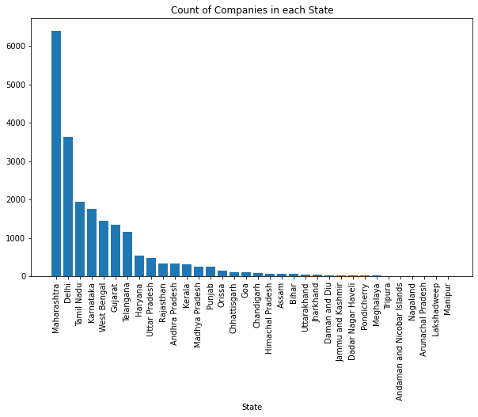

```python
# Plot number of companies in each State
plt.figure(figsize = (10, 6))
plt.bar(table["State"], table["Count"])
plt.title("Count of Companies in each State")
plt.xlabel("State")
plt.xticks(rotation = 90)
plt.show()
```

### Email ID

Email address.

```python
column = csr_spent_17_18["Email ID"]
column
```

```
0                sandeep.deshmukh@ril.com
1                  secretariat@ongc.co.in
2               rajendra.moholkar@tcs.com
3              sanjay.dongre@hdfcbank.com
4                   kgwalani@indianoil.in
                       ...
20970                 ccm@shapesindia.com
20971                       cs@vrl.net.in
20972    Jayadev.mishra@ttelectronics.com
20973           pathuri@natcopharma.co.in
20974            Saurabh.Jain@gmrgroup.in
Name: Email ID, Length: 20975, dtype: object
```

```python
print("No. of unique values:", len(column.unique()))
print("No. of null values:", len(column[column == "-NA-"]))

# Check for duplicates
counter = dict(Counter(column))
duplicates = { key:value for key, value in counter.items() if value > 1}
#print("Duplicates:", duplicates)
if len(duplicates) > 0:
    print("No. of duplicates:", len(duplicates))
```

```
No. of unique values: 17323
No. of null values: 5
No. of duplicates: 2071
```

```python
csr_spent_17_18[csr_spent_17_18["Email ID"].isin(duplicates)].sort_values('Email ID', ascending = False)
```

|  | Url | Company Name | CSR Spent 17-18 | Date of Incorporation | Class | RoC | Category | Sub Category | Listing Status | Registered Address | Zipcode | State | Email ID | Paid-up Capital (in INR Cr.) | Authorized Capital (in INR Cr.) |
| --- | --- | --- | --- | --- | --- | --- | --- | --- | --- | --- | --- | --- | --- | --- | --- |
| 3326 | https://csr.gov.in/companyprofile/dashboard.ph... | Zota Health Care Limited | 3200000 | 2000-07-12 | Public | RoC-Ahmedabad | Company limited by Shares | Non-govt company | Listed | ZOTA HOUSE 2/896 HIRA MODI STREETSAGRAMPURA 3... | 395002.0 | Gujarat | zotahealth@yahoo.com | ₹ 17.54 | ₹ 20.00 |
| 12596 | https://csr.gov.in/companyprofile/dashboard.ph... | Zota Health Care Limited | 0 | 2000-07-12 | Public | RoC-Ahmedabad | Company limited by Shares | Non-govt company | Unlisted | ZOTA HOUSE 2/896 HIRA MODI STREETSAGRAMPURA 3... | 395002.0 | Gujarat | zotahealth@yahoo.com | ₹ 17.54 | ₹ 20.00 |
| 19081 | https://csr.gov.in/companyprofile/dashboard.ph... | Taiyo Lucid Private Limited | 0 | 2002-08-23 | Private | RoC-Mumbai | Company limited by Shares | Non-govt company | Unlisted | 401 A NAVBHARAT ESTATEZAKARIA BUNDER ROADSEW... | 400015.0 | Maharashtra | yvaza@lucidgroup.com | ₹ 20.00 | ₹ 25.00 |
| 4042 | https://csr.gov.in/companyprofile/dashboard.ph... | Lucid Colloids Limited | 2400000 | 1996-05-23 | Public | RoC-Mumbai | Company limited by Shares | Non-govt company | Unlisted | 401 NAVBHARAT ESTATESZAKARIA BUNDER ROADSEWRI... | 400015.0 | Maharashtra | yvaza@lucidgroup.com | ₹ 5.50 | ₹ 10.00 |
| 3454 | https://csr.gov.in/companyprofile/dashboard.ph... | Vivimed Labs Limited | 3000000 | 1988-09-22 | Public | RoC-Bangalore | Company limited by Shares | Non-govt company | Listed | PLOT NO. 78-A,KOLHAR INDUSTRIAL AREA,BIDAR 58... | 585403.0 | Karnataka | yugandhar.kopparthi@vivimedlabs.com | ₹ 16.50 | ₹ 111.00 |
| ... | ... | ... | ... | ... | ... | ... | ... | ... | ... | ... | ... | ... | ... | ... | ... |
| 8819 | https://csr.gov.in/companyprofile/dashboard.ph... | The Mobilewallet Private Limited | 0 | 2015-07-30 | Private | RoC-Mumbai | Company limited by Shares | Non-govt company | Unlisted | Tower - 3, 3rd Floor, Equinox BusiOff. Bandra ... | 400070.0 | Maharashtra | -NA- | ₹ 19.08 | ₹ 25.00 |
| 12135 | https://csr.gov.in/companyprofile/dashboard.ph... | Central Social Welfare Board Pvt.ltd. | 0 | 1969-03-31 | Private | RoC-Delhi | Company Limited by Guarantee | Non-govt company | Unlisted | JEEVAN DEEP SANSAD MARG,NEWDELHI-110001 110001 | 110001.0 | Delhi | -NA- | ₹ 0.00 | ₹ 0.00 |
| 20117 | https://csr.gov.in/companyprofile/dashboard.ph... | Tanish Equity Services Private Limited | 0 | 2013-07-31 | Private | RoC-Mumbai | Company limited by Shares | Non-govt company | Unlisted | Flat No. 401, 4th Floor, D Wing, Bldg. No. I,O... | 400060.0 | Maharashtra | -NA- | ₹ 0.01 | ₹ 6.10 |
| 19665 | https://csr.gov.in/companyprofile/dashboard.ph... | Star Line Leasing Ltd | 0 | 1984-03-26 | Public | RoC-Kanpur | Company limited by Shares | Non-govt company | Unlisted | C-3,PANKI INDUSTRIAL ESTATEKANPUR 000000 | 0.0 | Uttar Pradesh | -NA- | ₹ 3.83 | ₹ 0.10 |
| 16894 | https://csr.gov.in/companyprofile/dashboard.ph... | Narmada Spinning Private Limited | 0 | 2014-06-26 | Private | RoC-Ahmedabad | Company limited by Shares | Non-govt company | Unlisted | Orchid Appartment, Bl. No. 202Opp. Ram Krupa D... | 360005.0 | Gujarat | -NA- | ₹ 10.40 | ₹ 10.50 |

5723 rows × 15 columns

### Paid-up Capital (in INR Cr.)

Actual amount that is paid by shareholders to the company.

```python
column = csr_spent_17_18["Paid-up Capital (in INR Cr.)"]
column
```

```
0        ₹ 6,333.50
1        ₹ 6,416.62
2          ₹ 197.04
3          ₹ 517.61
4        ₹ 4,855.90
            ...
20970        ₹ 1.82
20971       ₹ 33.92
20972        ₹ 0.02
20973        ₹ 0.42
20974    ₹ 2,450.00
Name: Paid-up Capital (in INR Cr.), Length: 20975, dtype: object
```

```python
#Turning objects into floats
amounts = column.apply(lambda x: str(x[1:]))
amounts = amounts.apply(lambda x: float(x.replace(',','')))
amounts
```

```
0        6333.50
1        6416.62
2         197.04
3         517.61
4        4855.90
          ...
20970       1.82
20971      33.92
20972       0.02
20973       0.42
20974    2450.00
Name: Paid-up Capital (in INR Cr.), Length: 20975, dtype: float64
```

```python
print("No. of unique values:", len(amounts.unique()))
print("No. of zero values:", len(amounts[amounts == 0]))

# Check for duplicates
counter = dict(Counter(amounts))
duplicates = { key:value for key, value in counter.items() if value > 1}
#print("Duplicates:", duplicates)
if len(duplicates) > 0:
    print("No. of duplicates:", len(duplicates))
```

```
No. of unique values: 5580
No. of zero values: 105
No. of duplicates: 2051
```

```python
#Statistics
amounts.describe()
```

```
count    20975.000000
mean       107.034567
std       1086.089780
min          0.000000
25%          0.580000
50%          3.920000
75%         18.180000
max      88086.540000
Name: Paid-up Capital (in INR Cr.), dtype: float64
```

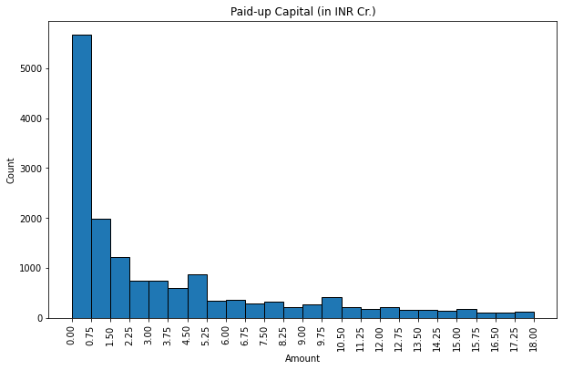

```python
#Histogram of bottom 75% Of Paid-up Capital
bins= np.linspace(0, 18, 25)
plt.figure(figsize = (10, 6))
plt.hist(amounts, bins=bins, edgecolor="k")
plt.title('Paid-up Capital (in INR Cr.)')
plt.ylabel('Count')
plt.xlabel('Amount')
plt.xticks(bins, rotation = 90);
```

### Authorized Capital (in INR Cr.)

Maximum value of shares that the company is legally authorized to issue to the shareholders.

```python
column = csr_spent_17_18["Authorized Capital (in INR Cr.)"]
column
```

```
0        ₹ 15,000.00
1        ₹ 15,000.00
2           ₹ 565.08
3           ₹ 650.00
4         ₹ 6,000.00
            ...
20970         ₹ 3.00
20971        ₹ 45.84
20972         ₹ 0.10
20973         ₹ 1.00
20974     ₹ 3,000.00
Name: Authorized Capital (in INR Cr.), Length: 20975, dtype: object
```

```python
#Turning objects into floats
amounts = column.apply(lambda x: str(x[1:]))
amounts = amounts.apply(lambda x: float(x.replace(',','')))
amounts
```

```
0        15000.00
1        15000.00
2          565.08
3          650.00
4         6000.00
           ...
20970        3.00
20971       45.84
20972        0.10
20973        1.00
20974     3000.00
Name: Authorized Capital (in INR Cr.), Length: 20975, dtype: float64
```

```python
print("No. of unique values:", len(amounts.unique()))
print("No. of zero values:", len(amounts[amounts == 0]))

# Check for duplicates
counter = dict(Counter(amounts))
duplicates = { key:value for key, value in counter.items() if value > 1}
#print("Duplicates:", duplicates)
if len(duplicates) > 0:
    print("No. of duplicates:", len(duplicates))
```

```
No. of unique values: 2022
No. of zero values: 82
No. of duplicates: 738
```

```python
#Statistics
amounts.describe()
```

```
count    20975.000000
mean       196.246741
std       1633.095200
min          0.000000
25%          1.000000
50%          6.000000
75%         29.000000
max      99000.000000
Name: Authorized Capital (in INR Cr.), dtype: float64
```

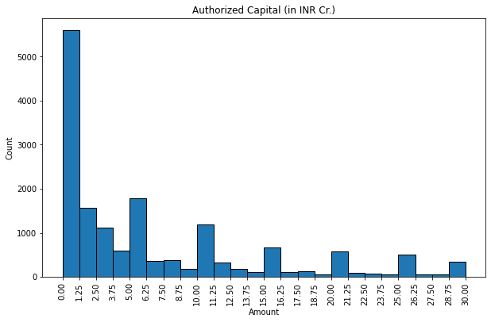

```python
#Histogram of bottom 75% Of Authorized Capital
bins= np.linspace(0, 30, 25)
plt.figure(figsize = (10, 6))
plt.hist(amounts, bins=bins, edgecolor="k")
plt.title('Authorized Capital (in INR Cr.)')
plt.ylabel('Count')
plt.xlabel('Amount')
plt.xticks(bins, rotation = 90);
```